# Video Game Sales Data

## By: Luke Bender

### December 16, 2017

### Introduction

Video games became wildly popular with arcade machines, but as technology progressed, home consoles were created, too. Before long, they had become a major factor in the electronic entertainment market. Since the 1970s, video games have become more and more popular, and [the global video game market is expected to have a value of over 100 billion USD by 2019](https://venturebeat.com/2016/04/21/video-games-will-become-a-99-6b-industry-this-year-as-mobile-overtakes-consoles-and-pcs/). I myself am a big fan of video games, but I also love to learn about their history and how the [video game industry](https://en.wikipedia.org/wiki/Video_game_industry) operates.  
Because video games have become such a huge market, marketing is critical to appeal to the right audience and to understand trends in people's interests in certain types of games. Because sales data is made public, not only can I analyze which games and systems have been most popular, but I can also notice trends into which genres will have a higher appeal in the future or into which companies might not be making as many popular games as they used to. If I were working for a video game company, I could use these data science techniques to help my company understand where the industry is headed and how we might be able to profit off of that. Of course, if that were my full-time job, I would also look at social media data to better grasp what people would like in games nowadays. However, for this project, I am only going to be looking at video game sales data.

This data is collected from the Kaggle dataset at https://www.kaggle.com/gregorut/videogamesales, where the data is in a csv file, 'vgsales.csv'. On the user's page, he states that he used BeautifulSoup to scrape the data himself from http://www.vgchartz.com, a database for video game hardware and software sales (this project will just be looking at software). The actual webpage for total software sales used for this project is at http://www.vgchartz.com/gamedb/. According to the Kaggle user's page, this dataset is current as of 10/26/16, so any games released since then, including Nintendo Switch games, are not covered. Additionally, the user states that this dataset contains all listed games that have sold at least 100,000 copies, of which there are 16,598.

Before I begin, I must import any important libraries. [Pandas](https://pandas.pydata.org/) is the main framework for storing and manipulating data in Python. [Numpy](http://www.numpy.org/) is a strong mathematical tool for scientific operations in Python. [Matplotlib](https://matplotlib.org/) is a library used to make plots in Python to help visualize your data. [Sklearn](http://scikit-learn.org/stable/) is a machine learning tool capable of power regression analysis.

```python
import pandas as pd
import numpy as np
import matplotlib.pyplot as plt
import sklearn.metrics
```

This project was completed using a [Jupyter Notebook](http://jupyter.org/) as part of Anaconda. You can download Anaconda at https://www.continuum.io, which comes packaged with the required libraries. The programming was done in Python 3. If you are viewing this from a GitHub URL, you can view it in a [Jupyter NBViewer](https://nbviewer.jupyter.org/).

### Collecting the Data

To start, first I must download the csv file from the website, move it to the same file as this Jupyter Notebook, and then read it into a Pandas [DataFrame](https://pandas.pydata.org/pandas-docs/stable/generated/pandas.DataFrame.html).

```python
sales = pd.read_csv('vgsales.csv')
sales.head()
```

|  | Rank | Name | Platform | Year | Genre | Publisher | NA_Sales | EU_Sales | JP_Sales | Other_Sales | Global_Sales |
| --- | --- | --- | --- | --- | --- | --- | --- | --- | --- | --- | --- |
| 0 | 1 | Wii Sports | Wii | 2006.0 | Sports | Nintendo | 41.49 | 29.02 | 3.77 | 8.46 | 82.74 |
| 1 | 2 | Super Mario Bros. | NES | 1985.0 | Platform | Nintendo | 29.08 | 3.58 | 6.81 | 0.77 | 40.24 |
| 2 | 3 | Mario Kart Wii | Wii | 2008.0 | Racing | Nintendo | 15.85 | 12.88 | 3.79 | 3.31 | 35.82 |
| 3 | 4 | Wii Sports Resort | Wii | 2009.0 | Sports | Nintendo | 15.75 | 11.01 | 3.28 | 2.96 | 33.00 |
| 4 | 5 | Pokemon Red/Pokemon Blue | GB | 1996.0 | Role-Playing | Nintendo | 11.27 | 8.89 | 10.22 | 1.00 | 31.37 |

I immeadiately observe a few things from just these 5 data points:

1. This dataset is ordered with the highest global sales first.
2. Nintendo has made many of the most popular games of all time, with the Wii being especially popular.
3. North American sales are approximately equal to sales from the rest of the world.
4. The sales are given in millions of units.
5. These are sales numbers for a game on an individaul platform (I verified this myself by checking the data). For example, [Grand Theft Auto V](https://en.wikipedia.org/wiki/Grand_Theft_Auto_V) for XBox 360 is a different data point and has different sales numbers from Grand Theft Auto V for PS3.

### Tidying the Data

Thankfully the person who scraped the data from the website did a great job to make sure that this data is already quite tidy and readily available for analysis. However, I still want to perform my own check to tidy the data to a form that I prefer. First, I want to create individual lists of all platforms, genres, and years to get a better understanding of what data I have and what needs to be fixed. For better readability, I will also sort these lists.  
To access each row of a Pandas DataFrame, you the [iterrows()](https://pandas.pydata.org/pandas-docs/stable/generated/pandas.DataFrame.iterrows.html) function, which returns an iterrable of each row. Each row is a tuple of the index and the series containg the rest of the information, which you can access with row[1]. A Pandas [Series](https://pandas.pydata.org/pandas-docs/stable/generated/pandas.Series.html) is an array-like data structure that has specific values for each column in the DataFrame. You can see the following code on how to access data from a DataFrame. The append() function is a list function to place the given value at the end of a list (i.e., if you're list = [5,2], and you call append(-4), you get [5,2,-4]).

```python
platforms = []
genres = []
years = []

for row in sales.iterrows():
    series = row[1]
    plat = series['Platform']
    gen = series['Genre']
    year = series['Year']

    if(plat not in platforms):
        platforms.append(plat)

    if(gen not in genres):
        genres.append(gen)

    if(year not in years):
        years.append(year)

platforms = sorted(platforms)
genres = sorted(genres)
years = sorted(years)
```

Now I first want to see all platforms represented in dataset. If you are unaware, the platform is the system or console on which that the video game is played. Because of constantly improving technology and a strong desire for the most up to date graphics, companies tend to have consoles run on a life cycle before moving onto the next one. The general life cycle of a video game console is generally around 5-7 years but depends on the technology and popularity of the console. See [this article](http://wololo.net/2015/10/27/life-cycle-console/) for more information about the life cycles of the major systems over the past 30 years.

```python
for x in platforms:
    print(x, end = ', ')
```

```
2600, 3DO, 3DS, DC, DS, GB, GBA, GC, GEN, GG, N64, NES, NG, PC, PCFX, PS, PS2, PS3, PS4, PSP, PSV, SAT, SCD, SNES, TG16, WS, Wii, WiiU, X360, XB, XOne,
```

There are 31 platforms in this list, and I will refer to them by their abbreaviations for this project. But for the sake of completion, the abbreviations correspond to:

- NES - [Nintendo Entertainment System](https://en.wikipedia.org/wiki/Nintendo_Entertainment_System)
- SNES - [Super Nintendo Entertainment System](https://en.wikipedia.org/wiki/Super_Nintendo_Entertainment_System)
- N64 - [Nintendo 64](https://en.wikipedia.org/wiki/Nintendo_64)
- GC - [Nintendo Gamecube](https://en.wikipedia.org/wiki/GameCube)
- Wii - [Nintendo Wii](https://en.wikipedia.org/wiki/Wii)
- WiiU - [Nintendo Wii U](https://en.wikipedia.org/wiki/Wii_U)
- GB - [Nintendo Gameboy](https://en.wikipedia.org/wiki/Game_Boy)
- GBA - [Nintendo Gameboy Advance](https://en.wikipedia.org/wiki/Game_Boy_Advance)
- DS - [Nintendo DS](https://en.wikipedia.org/wiki/Nintendo_DS)
- 3DS - [Nintendo 3DS](https://en.wikipedia.org/wiki/Nintendo_3DS)
- PS - Sony Playstation
- PS2 - [Sony Playstation 2](https://en.wikipedia.org/wiki/PlayStation_2)
- PS3 - [Sony Playstation 3](https://en.wikipedia.org/wiki/PlayStation_3)
- PS4 - [Sony Playstation 4](https://en.wikipedia.org/wiki/PlayStation_4)
- PSP - [Sony Playstation Portable](https://en.wikipedia.org/wiki/PlayStation_Portable)
- PSV - [Sony Playstation Vita](https://en.wikipedia.org/wiki/PlayStation_Vita)
- XB - Microsoft XBox
- X360 - [Microsoft XBox 360](https://en.wikipedia.org/wiki/Xbox_360)
- XOne - [Microsoft XBox One](https://en.wikipedia.org/wiki/Xbox_One)
- Gen - [Sega Genesis](https://en.wikipedia.org/wiki/Sega_Genesis)
- SCD - [Sega CD](https://en.wikipedia.org/wiki/Sega_CD)
- SAT - [Sega Saturn](https://en.wikipedia.org/wiki/Sega_Saturn)
- DC - [Sega Dreamcast](https://en.wikipedia.org/wiki/Dreamcast)
- GG - [Sega Game Gear](https://en.wikipedia.org/wiki/Game_Gear)
- PC - [Personal Computer](https://en.wikipedia.org/wiki/PC_game)
- 2600 - [Atari 2600](https://en.wikipedia.org/wiki/Atari_2600)
- WS - WonderSwan
- NG - Neo Geo
- TG16 - TurboGrafx-16
- PCFX - PC-FX
- 3DO - [3DO Interactive Multiplayer](https://en.wikipedia.org/wiki/3DO_Interactive_Multiplayer)

```python
for x in genres:
    print(x, end = ', ')
```

```
Action, Adventure, Fighting, Misc, Platform, Puzzle, Racing, Role-Playing, Shooter, Simulation, Sports, Strategy,
```

These all seem typical, except for "Misc", which indicates that the genre is miscellaneous.

I also want to see what years are represented:

```python
for x in years:
    print(x, end = ', ')
```

```
1980.0, 1981.0, 1982.0, 1983.0, 1984.0, 1985.0, 1986.0, 1987.0, 1988.0, 1989.0, 1990.0, 1991.0, 1992.0, 1993.0, 1994.0, 1995.0, 1996.0, 1997.0, 1998.0, 1999.0, 2000.0, 2001.0, 2002.0, 2003.0, 2004.0, 2005.0, 2006.0, 2007.0, 2008.0, 2009.0, 2010.0, 2011.0, 2012.0, 2013.0, 2014.0, 2015.0, nan, 2016.0,…
```

First of all, that is a lot of missing values, and I'll fix that in a moment. However, I notice something strange: this data is supposedly updated as of 2016, yet there are games from 2017 and 2020? Because these are most likely errors, I should remove them, but I am at least curious about which games these are, so I want to check them out really quick:

```python
for row in sales.iterrows():
    if(row[1]['Year'] > 2016):
        print(row[1])
        print("")
```

```
Rank                              5959
Name            Imagine: Makeup Artist
Platform                            DS
Year                              2020
Genre                       Simulation
Publisher                      Ubisoft
NA_Sales                          0.27
EU_Sales                             0
JP_Sales                             0
Other_Sales                       0.02
Global_Sales                      0.29
Name: 5957, dtype: object

Rank                                                       14393
Name            Phantasy Star Online 2 Episode 4: Deluxe Package
Platform                                                     PS4
Year                                                        2017
Genre                                               Role-Playing
Publisher                                                   Sega
NA_Sales                                                       0
EU_Sales                                                       0
JP_Sales                                                    0.03
Other_Sales                                                    0
Global_Sales                                                0.03
Name: 14390, dtype: object

Rank                                                       16244
Name            Phantasy Star Online 2 Episode 4: Deluxe Package
Platform                                                     PSV
Year                                                        2017
Genre                                               Role-Playing
Publisher                                                   Sega
NA_Sales                                                       0
EU_Sales                                                       0
JP_Sales                                                    0.01
Other_Sales                                                    0
Global_Sales                                                0.01
Name: 16241, dtype: object

Rank                                       16441
Name            Brothers Conflict: Precious Baby
Platform                                     PSV
Year                                        2017
Genre                                     Action
Publisher                           Idea Factory
NA_Sales                                       0
EU_Sales                                       0
JP_Sales                                    0.01
Other_Sales                                    0
Global_Sales                                0.01
Name: 16438, dtype: object
```

These 4 games seem like errors from the database, and their sales numbers are very low. It would be easiest if I just got rid of these 4 games. I also want to get rid of the nan values. Rather than manipulate the original dataset in any way, I'll create a new list of years without these bad values. The numpy function isnan() is useful here.

```python
good_years = []
for x in years:
    if(not np.isnan(x) and x < 2017):
        good_years.append(x)

for x in good_years:
    print(x, end = ', ')
```

```
1980.0, 1981.0, 1982.0, 1983.0, 1984.0, 1985.0, 1986.0, 1987.0, 1988.0, 1989.0, 1990.0, 1991.0, 1992.0, 1993.0, 1994.0, 1995.0, 1996.0, 1997.0, 1998.0, 1999.0, 2000.0, 2001.0, 2002.0, 2003.0, 2004.0, 2005.0, 2006.0, 2007.0, 2008.0, 2009.0, 2010.0, 2011.0, 2012.0, 2013.0, 2014.0, 2015.0, 2016.0,
```

Now my list good_years has all the valid years (and is sorted). However, the games listed with missing years still bug me slightly, so I want to check how many games have missing years:

```python
i = 0
for row in sales.iterrows():
    if(np.isnan(row[1]['Year'])):
        i = i + 1
i
```

```
271
```

271 games out of 16,000 are listed without a year, so there is only around 1-2% of my data that are not perfect. I am not sure as to why there is no year listed for these games. Intuitively, I would expect every somewhat popular game to have recorded basic information like year that they were released, so I would think that maybe these games probably didn't sell well or weren't very popular if the data for that game is incomplete. To test this theory, I'll print the sales of each game with a nan value for the year released.

```python
bad = []
for row in sales.iterrows():
    if(np.isnan(row[1]['Year'])):
        print(row[1]['Global_Sales'], end = ", ")
```

```
5.23, 3.49, 3.17, 3.0, 2.53, 2.48, 2.39, 2.39, 2.26, 2.11, 1.63, 1.62, 1.46, 1.36, 1.32, 1.3, 1.25, 1.22, 1.19, 1.11, 1.04, 1.03, 0.99, 0.98, 0.98, 0.97, 0.97, 0.95, 0.91, 0.9, 0.86, 0.86, 0.83, 0.83, 0.82, 0.8, 0.74, 0.74, 0.72, 0.69, 0.67, 0.64, 0.63, 0.63, 0.62, 0.6, 0.59, 0.58, 0.58, 0.54, 0.54,…
```

It turns out, quite a few of these games sold over a million copies, so perhaps these games just don't have their year in the dataset. My next idea was to check the first item in the dataset and actually look it up in the [original dataset](http://www.vgchartz.com/gamedb/).

```python
for row in sales.iterrows():
    if(np.isnan(row[1]['Year'])):
        print(row[1])
        break
```

```
Rank                        180
Name            Madden NFL 2004
Platform                    PS2
Year                        NaN
Genre                    Sports
Publisher       Electronic Arts
NA_Sales                   4.26
EU_Sales                   0.26
JP_Sales                   0.01
Other_Sales                0.71
Global_Sales               5.23
Name: 179, dtype: object
```

When I go into the webpage now (Decemeber 15, 2017), Madden NFL 2004 for the PS2 has moved down to rank 191, and its year is listed as N/A. According to its [Wikipedia article](https://en.wikipedia.org/wiki/Madden_NFL_2004), this game was released in 2003 (in all regions, too), so I guess there was just an issue with the original data colletion.

Nevertheless, this dataset was mostly tidied already, for which I am very thankful. The only real issue I have for this dataset are the years, but I don't think I need to create a whole new dataframe without the bad years. Rather, when I iterrate over the dataset, I can simply check whether the year is in the good_years list, otherwise I can skip that row.

### Exploratory Data Analysis

Now I want to do some initial analysis of the data to understand general trends and just learn more about the data. My first thought was to examine total global sales of all games per year. Here I will be using the Matplotlib plot() function to plot the global sales over time. The plot function takes two lists as parameters, the x values and the y values. I create a hash with the keys being all the valid years and the values are the global sales for that year. Then, when I call the the plot function, I have to cast the keys and values to lists. You can see how to create a line graph in Matplotlib [here](https://matplotlib.org/2.0.2/users/pyplot_tutorial.html).

```python
global_sales = {}
for x in good_years:
    global_sales[x] = 0

for row in sales.iterrows():
    series = row[1]
    year = series['Year']

    if(not np.isnan(year) and year < 2017):
        global_sales[year] = global_sales[year] + series['Global_Sales']
```

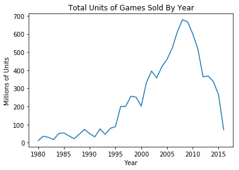

```
The mean total sales per year (in millions) is: 238.378918919
and the standard deviation is: 208.330158108
```

```python
plt.plot(list(global_sales.keys()), list(global_sales.values()))
plt.title("Total Units of Games Sold By Year")
plt.xlabel("Year")
plt.ylabel("Millions of Units")
plt.show()

print('The mean total sales per year (in millions) is: ' + str(np.mean(list(global_sales.values()))) +
      '\nand the standard deviation is: ' + str(np.std(list(global_sales.values()))))
```

It is important to remember that the graph above leaves out two major facts. First, around 1-2% of games in the dataset did not have a year listed, and since it would take far too long to manually update that for each game, it is easier to leave them out for this graph. Second, this only includes games that have sold at least 100,000 units, so this does not fully represent the entire market for video games. However, I will be assuming that those less popular games are negligible to the hundreds of millions of units that have been sold collectively for the popular games.

From this graph, I notice a few important trends that I can try to explain. First, from 1980 - 1995, there is a slow but noticeable increase in overall sales of games as they started to become popular. However, around 1995, the 3D revolution hit gaming. Home consoles were released with revolutionary 3D graphics, and it is clear that this sparked a huge increase in interest in games. It also helps that this period included a large number of highly regarded games, such as [Final Fantasy VII](https://en.wikipedia.org/wiki/Final_Fantasy_VII) and [Super Mario 64](https://en.wikipedia.org/wiki/Super_Mario_64), which were notorious as being "system sellers". Interest in gaming clearly continues to exponenetially climb until the mid-2000s, where it peaks. This is most likely due to a larger appeal to the "casual gamer" with the Nintendo Wii being a huge success.

```python
sales.head(10)
```

|  | Rank | Name | Platform | Year | Genre | Publisher | NA_Sales | EU_Sales | JP_Sales | Other_Sales | Global_Sales |
| --- | --- | --- | --- | --- | --- | --- | --- | --- | --- | --- | --- |
| 0 | 1 | Wii Sports | Wii | 2006.0 | Sports | Nintendo | 41.49 | 29.02 | 3.77 | 8.46 | 82.74 |
| 1 | 2 | Super Mario Bros. | NES | 1985.0 | Platform | Nintendo | 29.08 | 3.58 | 6.81 | 0.77 | 40.24 |
| 2 | 3 | Mario Kart Wii | Wii | 2008.0 | Racing | Nintendo | 15.85 | 12.88 | 3.79 | 3.31 | 35.82 |
| 3 | 4 | Wii Sports Resort | Wii | 2009.0 | Sports | Nintendo | 15.75 | 11.01 | 3.28 | 2.96 | 33.00 |
| 4 | 5 | Pokemon Red/Pokemon Blue | GB | 1996.0 | Role-Playing | Nintendo | 11.27 | 8.89 | 10.22 | 1.00 | 31.37 |
| 5 | 6 | Tetris | GB | 1989.0 | Puzzle | Nintendo | 23.20 | 2.26 | 4.22 | 0.58 | 30.26 |
| 6 | 7 | New Super Mario Bros. | DS | 2006.0 | Platform | Nintendo | 11.38 | 9.23 | 6.50 | 2.90 | 30.01 |
| 7 | 8 | Wii Play | Wii | 2006.0 | Misc | Nintendo | 14.03 | 9.20 | 2.93 | 2.85 | 29.02 |
| 8 | 9 | New Super Mario Bros. Wii | Wii | 2009.0 | Platform | Nintendo | 14.59 | 7.06 | 4.70 | 2.26 | 28.62 |
| 9 | 10 | Duck Hunt | NES | 1984.0 | Shooter | Nintendo | 26.93 | 0.63 | 0.28 | 0.47 | 28.31 |

Out of the top 10 best selling games of all time, 5 are on the Wii ([Wii Sports](https://en.wikipedia.org/wiki/Wii_Sports) did come packaged with the Wii, which explains why its the best selling game on an individual platform ever). Evidently, this success was unsustainable as the interest fell back to numbers before the Wii was released. The large drop-off at the end, however, is misleading. These are only sales numbers as of 10/26/16, and many games haven't sold nearly as many as they will after a few years, so it's probably only safe to analyze up to the end of 2015.

The cumulative total of game units that the Wii had sold was:

```python
total = 0
for row in sales.iterrows():
    if(row[1]['Platform'] == 'Wii'):
        total = total + row[1]['Global_Sales']

total
```

```
926.7099999999971
```

This is nearly 1 billion units. So the Wii was obviously quite successful. I am also curious to see how the main competitors, the PS3 and XBox 360, did in their lifetime as well:

```python
ps, xb = 0, 0
for row in sales.iterrows():
    platform = row[1]['Platform']
    if(platform == 'PS3'):
        ps = ps + row[1]['Global_Sales']

    if(platform == 'X360'):
        xb = xb + row[1]['Global_Sales']

print('PS3: ' + str(ps))
print('XBox 360: ' + str(xb))
```

```
PS3: 957.8399999999987
XBox 360: 979.9599999999996
```

```python
ps, xb, wii = 0, 0, 0
for row in sales.iterrows():
    platform = row[1]['Platform']
    if(platform == 'Wii'):
        wii = wii +  + row[1]['NA_Sales']

    if(platform == 'PS3'):
        ps = ps + row[1]['NA_Sales']

    if(platform == 'X360'):
        xb = xb + row[1]['NA_Sales']

print('Wii: ' + str(wii))
print('PS3: ' + str(ps))
print('XBox 360: ' + str(xb))
```

```
Wii: 507.7099999999991
PS3: 392.2599999999998
XBox 360: 601.0499999999992
```

I can also evaluate the average global sales of all games for each year (i.e. each year has an average amount of global sales per game). I am curious to see if this has a similar shape as before. However, since there are many more games released more recently, the averages will probably go down, so I predict that the graph will level out after at some point. Let's see how it looks:

```python
num_games = {}
total_sold = {}
avg = {}
for x in good_years:
    num_games[x] = 0
    total_sold[x] = 0

for row in sales.iterrows():
    series = row[1]
    year = series['Year']

    if(not np.isnan(year) and year < 2017):
        num_games[year] = num_games[year] + 1
        total_sold[year] = total_sold[year] + series['Global_Sales']

for x in good_years:
    avg[x] = total_sold[x]/num_games[x]
```

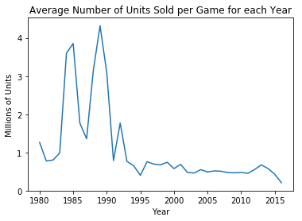

```python
plt.plot(list(avg.keys()), list(avg.values()))
plt.xlabel('Year')
plt.ylabel('Millions of Units')
plt.title('Average Number of Units Sold per Game for each Year')
plt.show()
```

This graph is very interesting to me. Once gaming became more popular, many new companies entered the market, and many new games were created. Because not every game can't do amazingly well, the sheer amount of games brings the average down. I am surprised by the how even/flat the graph is for the last 20 years, especially during the Wii era. There were many games that sold a very large amount, but that lead to a lot of new, uninspiring games created to profit off the new success (known as [shovelware](https://en.wikipedia.org/wiki/Shovelware)). The Wii is [well-documented](http://www.gameinformer.com/b/news/archive/2009/09/27/feature-wii-software-problem-shovelware.aspx) for having many shovelware games to take advantage of the Wii's success. A [user on a Nintendo forum](http://nintendoage.com/forum/messageview.cfm?StartRow=1&catid=5&threadid=170644) even collected every Wii game ever released, most of which was shovelware. I am very surprised by how the average stays consistent over this time period, but I guess that is a testament to how popular gaming has become.

Another facet that I am interested in evaluating is the percentage of each genre represented. Remember that I already have every genre stored in the list genres.

```python
gen_values = {}
for x in genres:
    gen_values[x] = 0

for row in sales.iterrows():
    genre = row[1]['Genre']
    gen_values[genre] = gen_values[genre] + 1

gen_values
```

```
{'Action': 3316,
 'Adventure': 1286,
 'Fighting': 848,
 'Misc': 1739,
 'Platform': 886,
 'Puzzle': 582,
 'Racing': 1249,
 'Role-Playing': 1488,
 'Shooter': 1310,
 'Simulation': 867,
 'Sports': 2346,
 'Strategy': 681}
```

Of course, seeing this visually would be easier. A bar graph would be good to compare the differnt values since the x values are categorical data. The code for creating bar graphs can be seen [here](https://pythonspot.com/matplotlib-bar-chart/).

```python
x_values = list(gen_values.keys())
y_values = list(gen_values.values())
pos = np.arange(len(x_values))
```

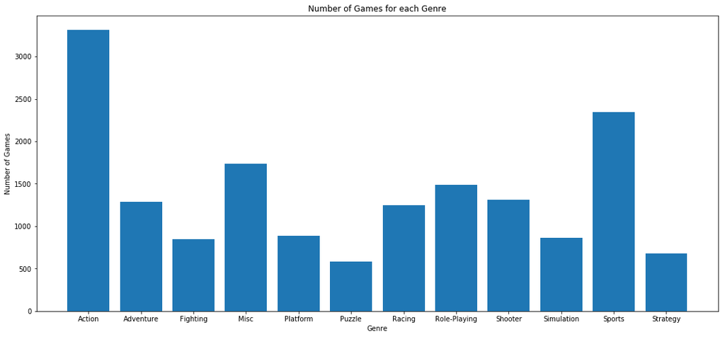

```
The average number of games per genre is: 1383.16666667
and the standard deviation is: 751.010855817
```

```python
# Setting the size to be bigger, default is [8,6] from what I found online.
plt.rcParams["figure.figsize"] = [18, 8]

plt.bar(pos, y_values, align='center')
plt.xticks(pos, x_values)
plt.xlabel('Genre')
plt.ylabel('Number of Games')
plt.title('Number of Games for each Genre')

plt.show()

print('The average number of games per genre is: ' + str(np.mean(y_values))
     + '\nand the standard deviation is: ' + str(np.std(y_values)))
```

I apologize if this graph is too big; I had to play with the size to make the words on the x-axis not overlap each other. I had trouble configuring the right size parameters, but this seems to work fine. I obtained this information from [here](https://codeyarns.com/2014/10/27/how-to-change-size-of-matplotlib-plot/) if you want to find out for yourself. I think constantly changing it and re-running the code can screw it up, so it might be in the best interest to restarting the Kernel if you are running this in a Jupyter Notebook.

So action games and sports are the most popular, while puzzle and strategy are the least popular. I'm now interested in when action games became popular, and also what the most popular action games are. First, I want to see the trends in total units of action games sold per year:

```python
action = {}
for x in good_years:
    action[x] = 0

for row in sales.iterrows():
    series = row[1]
    year = series['Year']
    genre = series['Genre']


    if(genre == 'Action' and not np.isnan(year) and year < 2017):
        action[year] = action[year] + series['Global_Sales']
```

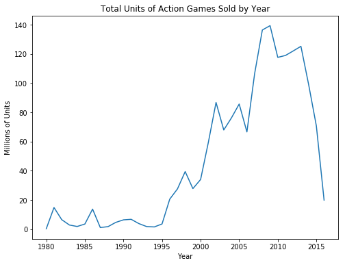

```
The average number of Action games (in millions) sold per year is: 46.5640540541
 and the standard deviaiton is: 46.9212699685
```

```python
# Default is [8,6] from what I found online, so reset back to normal size
plt.rcParams["figure.figsize"] = [8,6]

plt.plot(list(action.keys()), list(action.values()))
plt.xlabel('Year')
plt.ylabel('Millions of Units')
plt.title('Total Units of Action Games Sold by Year')

plt.show()

print('The average number of Action games (in millions) sold per year is: ' + str(np.mean(list(action.values())))
     + '\n and the standard deviaiton is: ' + str(np.std(list(action.values()))))
```

First, this seems to correlate directly with total game sales per year. Second, action games exploded in popularity once 3D graphics became more realistic and more powerful consoles were created to allow for precise movement and realistic physics. I am also interested to know what the most popular action game is, and all I need to do is find the first action game in the dataset, print it out, and break from the loop:

```python
for row in sales.iterrows():
    if(row[1]['Genre'] == 'Action'):
        print(row[1])
        break
```

```
Rank                              17
Name              Grand Theft Auto V
Platform                         PS3
Year                            2013
Genre                         Action
Publisher       Take-Two Interactive
NA_Sales                        7.01
EU_Sales                        9.27
JP_Sales                        0.97
Other_Sales                     4.14
Global_Sales                    21.4
Name: 16, dtype: object
```

```python
total = 0
for row in sales.iterrows():
    if(row[1]['Name'] == 'Grand Theft Auto V'):
        total = total + row[1]['Global_Sales']

total
```

```
55.92
```

According to the data, GTA V has collectively sold 56 million copies by October 2016. However, I found [this IGN article](http://www.ign.com/articles/2016/11/02/grand-theft-auto-5-has-now-shipped-70-million-units) posted on November 2, 2016 where the developers announced they had sold 70 million copies. The difference could be because IGN reported the total number shipped whereas the data I have could be the number sold in stores. Or it could simply be because the website wasn't fully up to date in its collection. Either way, GTA V was an incredibly successful and popular game that sold millions, and it is probably the most popular action game of all time.

Earlier in the project I had noted that North American sales seemed to rival the rest of the world. I want to see numerically how true this is. However, there are over 16,000 games in the dataset, so comparing the sales for eah individual game would be excessive. Instead, I will mimic the first graph that I made and compare the cumulative sales for each game over each year. I will take the cumulative total sales and subtract the North American cumulative sales, and graph that line graph over time.

```python
na, world = {}, {}
for x in good_years:
    na[x] = 0
    world[x] = 0

for row in sales.iterrows():
    series = row[1]
    year = series['Year']

    if(not np.isnan(year) and year < 2017):
        na[year] = na[year] + series['NA_Sales']
        world[year] = world[year] + series['Global_Sales']
```

```python
diff = {}
for x in good_years:
    diff[x] = world[x] - na[x]
```

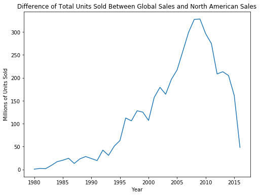

```python
plt.plot(list(diff.keys()), list(diff.values()))
plt.xlabel('Year')
plt.ylabel('Millions of Units Sold')
plt.title('Difference of Total Units Sold Between Global Sales and North American Sales')
plt.show()
```

These exploratory data analyses gave me quite interesting information. Video games exploded in popularity in 1995 with the new 3D graphics and many terrific games, and then again in the mid 2000s with the advent of the Wii. During these times, video games became more popular internatioanlly as well, and gaming overall quickly became a huge global market. Action games became incredibly common with this new widespread interest in gaming and more powerful systems, which is quite evident in a game as advanced as Grand Theft Auto V. Of course, it was the casual gaming market that caused another large boom for gaming, which is why Wii Sports, a pack in title with the Wii, is the most popular game of all time on an individual platform.

### Machine Learning and Hypothesis Testing

Machine learning is about taking your data and using it to make predictions for other datasets. I decided the best way I could use machine learning for this dataset is to predict what the best selling genres nowadays are. What I want to do is use machine learning techniques to evaluate the distribution of games for each genre up to 2015, use this to predict the genre distribution for 2016, and then compare the results to the actual distribution given in the report above. This is known as [supervised learning](https://en.wikipedia.org/wiki/Supervised_learning), where you use training data to predict future data. I will be using numpy's [polyfit](https://docs.scipy.org/doc/numpy-1.13.0/reference/generated/numpy.polyfit.html), which will return a polynomial of best fit that minimizes the least squares error. Furthermore, I will have to perform this for each of the genres separetly and then compare them at the end. The followng code will take each genre and give it a hash where the keys are the years and the values are the percentage of games are that genre for the given year.

```python
total = {} # maps year -> total games in that year

# maps year -> percent of games in that genre in that year
action = {}
adventure = {}
fighting = {}
misc = {}
plat = {}
puz = {}
racing = {}
rpg = {}
shooter = {}
sim = {}
sports = {}
strat = {}


for x in good_years:
    if(x < 2016):
        total[x] = 0
        action[x] = 0
        adventure[x] = 0
        fighting[x] = 0
        misc[x] = 0
        plat[x] = 0
        puz[x] = 0
        racing[x] = 0
        rpg[x] = 0
        shooter[x] = 0
        sim[x] = 0
        sports[x] = 0
        strat[x] = 0

for row in sales.iterrows():
    series = row[1]
    genre = series['Genre']
    year = series['Year']

    if(not np.isnan(year) and year < 2016):
        total[year] = total[year] + 1

        if(genre == 'Action'):
            action[year] = action[year] + 1

        if(genre == 'Adventure'):
            adventure[year] = adventure[year] + 1

        if(genre == 'Fighting'):
            fighting[year] = fighting[year] + 1

        if(genre == 'Misc'):
            misc[year] = misc[year] + 1

        if(genre == 'Platform'):
            plat[year] = plat[year] + 1

        if(genre == 'Puzzle'):
            puz[year] = puz[year] + 1

        if(genre == 'Racing'):
            racing[year] = racing[year] + 1

        if(genre == 'Role-Playing'):
            rpg[year] = rpg[year] + 1

        if(genre == 'Shooter'):
            shooter[year] = shooter[year] + 1

        if(genre == 'Simulation'):
            sim[year] = sim[year] + 1

        if(genre == 'Sports'):
            sports[year] = sports[year] + 1

        if(genre == 'Strategy'):
            strat[year] = strat[year] + 1

for x in good_years:
    if(x < 2016):
        action[x] = action[x]/total[x]
        adventure[x] = adventure[x]/total[x]
        fighting[x] = fighting[x]/total[x]
        misc[x] = misc[x]/total[x]
        plat[x] = plat[x]/total[x]
        puz[x] = puz[x]/total[x]
        racing[x] = racing[x]/total[x]
        rpg[x] = rpg[x]/total[x]
        shooter[x] = shooter[x]/total[x]
        sim[x] = sim[x]/total[x]
        sports[x] = sports[x]/total[x]
        strat[x] = strat[x]/total[x]
```

These hashes have the percentage distribution of each genre for each year up to 2015. Now I want to calculate the percent distribution of the genres for 2016:

```python
curr = {} # maps genre -> percent of games with that genre in 2016
total = 0
for x in genres:
    curr[x] = 0

for row in sales.iterrows():
    series = row[1]
    year = series['Year']

    if(not np.isnan(year) and year == 2016):
        total = total + 1
        genre = series['Genre']
        curr[genre] = curr[genre] + 1

for x in curr:
    curr[x] = curr[x]/total
```

```python
pred = {}
for x in genres:
    pred[x] = 0

def create_fit(deg):
    z = np.polyfit(list(action.keys()), list(action.values()), deg)
    p = np.poly1d(z)
    pred['Action'] = p(2016)

    z = np.polyfit(list(adventure.keys()), list(adventure.values()), deg)
    p = np.poly1d(z)
    pred['Adventure'] = p(2016)

    z = np.polyfit(list(fighting.keys()), list(fighting.values()), deg)
    p = np.poly1d(z)
    pred['Fighting'] = p(2016)

    z = np.polyfit(list(plat.keys()), list(plat.values()), deg)
    p = np.poly1d(z)
    pred['Platform'] = p(2016)

    z = np.polyfit(list(puz.keys()), list(puz.values()), deg)
    p = np.poly1d(z)
    pred['Puzzle'] = p(2016)

    z = np.polyfit(list(rpg.keys()), list(rpg.values()), deg)
    p = np.poly1d(z)
    pred['Role-Playing'] = p(2016)

    z = np.polyfit(list(shooter.keys()), list(shooter.values()), deg)
    p = np.poly1d(z)
    pred['Shooter'] = p(2016)

    z = np.polyfit(list(sim.keys()), list(sim.values()), deg)
    p = np.poly1d(z)
    pred['Simulation'] = p(2016)

    z = np.polyfit(list(sports.keys()), list(sports.values()), deg)
    p = np.poly1d(z)
    pred['Sports'] = p(2016)

    z = np.polyfit(list(strat.keys()), list(strat.values()), deg)
    p = np.poly1d(z)
    pred['Strategy'] = p(2016)
```

Now I want to find the degree that minimizes error associated with the best fit polynomials. I can simply evaluate each of the possible degrees and look at the errors to find the minimum. Through personal testing, any degree higher than 6 will start overfitting the graph, and polyfit will throw an error, so I only need to check degree 0 through 5.

```python
for deg in range(6):
    create_fit(deg)
    total = 0
    for x in genres:
        diff = (pred[x] - curr[x])
        total = total + (diff*diff)
    print(total)
```

```
0.0437427743807
0.0316497402274
0.0184196465413
0.0223491913875
0.0246209922941
0.0528745183909
```

So a degree of 2 is needed to give the best prediction. This means that the data is best represented by a quadratic graph. How good are the predictions? According to the above data, the sum of the root square error = sqrt(.018) = .13. Keep in mind that the data themselves are percentage values as a decimal, so they are all between 0 and 1. To see how well these correlate, I will perform a hypothesis test on the two data sets.

When you perform [hypothesis testing](https://en.wikipedia.org/wiki/Statistical_hypothesis_testing), you let the null hypothesis be that there is no relationship between your two datasets, while the alternative hypothesis be that there is a realtionship. One way to test for this is to use the correlation $R^2$ score, known as the [coefficient of determination](https://en.wikipedia.org/wiki/Coefficient_of_determination), which is always between 0 and 1. A value of 0 indicates that there is absolutely no relationship, while a value of 1 indiciates an exact one to one correspondence. The closer the value is to 1, the better the relationship. I can use sklearn to identify what my $R^2$ value is:

```python
r2 = sklearn.metrics.r2_score(list(pred.values()), list(curr.values()))
print(r2)
```

```
0.800645485929
```

This is a very high $R^2$, so I know that there is a very strong relationship between the two datasets. Therefore, I can conclude that my predicted values for the distribution of the genres in 2016 are good estimates for the actual distribution from the dataset.